# Range fill: what a range cell no model covers is worth (SHARE_BASIS, RANGE_FILL)

Four species under the taxon basis, the cell basis with the er, presence and calibrated-mean fills: maps and zone shares

Published

2026-11-02

## 1 Goal

v11’s Call 2 asks for **single counting**: the merged value of a cell should be the species’ suitability there, and extinction risk should enter once, as the weight at scoring. The v4 to v10 rule values a range cell `max(er_score, suitability)`, so the governing risk is baked into the surface and multiplied in again at scoring. The new flag `SHARE_BASIS=cell` values a range cell by its suitability alone wherever a suitability model covers it. That leaves one term open: **a range cell no suitability model covers**. `RANGE_FILL` decides it:

- `er`: the cell is worth the governing `er_score` on the 0 to 100 scale (an MBTA bird: 10, an Endangered whale: 100). This is what the DPS rule has done since v9 and what the fold-in’s density taxa inherited. Scoring multiplies by the same number again, so such a cell scores `er_score^2 / 100`.
- `presence`: the cell is worth 100, the range taken as presence. Scoring multiplies by the risk once.
- a **calibrated mean** (not built yet): the cell is worth what an average modelled cell of the species is worth, the mean of the suitability model over the cells it covers (for a density taxon, the survey’s mean percentile value over its domain, after calibration). The unmodelled range then neither vanishes (er for a low-risk species) nor swamps the model (presence).

For a **range-only** species the fill is a constant over the whole range, so the share (value divided by the species’ own total) is the same under every fill. The fill matters for species that have a model over part of their range: the density seabirds (survey domain vs the rest of their BirdLife range), the DPS species (AquaMaps over part of the listed footprint), and any range-and-AquaMaps taxon whose range extends beyond AquaMaps’ cells.

This notebook reconstructs four species’ merged surfaces from the committed merge input (`mc_parts`) with the msens rules under each setting, maps them, and tabulates their global totals and Program-Area shares. It changes nothing in the pipeline. The zone edits (occurrence gate, encounter weight) are not applied here: they wrap every setting identically.

```r
librarian::shelf(DBI, dplyr, duckdb, fs, ggplot2, glue, here, logger, readr, sf, tidyr, quiet = T)
source(here("libs/paths.R"))
dir_atlas <- glue("{dir_big_v}/marine-atlas")
dir_parts <- glue("{dir_atlas}/mc_parts")
merge_db  <- glue("{dir_atlas}/merge.duckdb")
stopifnot(dir_exists(dir_parts), file_exists(merge_db), file_exists(sdm_db))
g <- msens::grid_spec_for("global05")
con <- dbConnect(duckdb())
dbExecute(con, "SET threads = 4; SET memory_limit = '6GB'")
```

```
[1] 0
```

```r
dbExecute(con, glue("SET temp_directory = '{dir_big}/derived/tmp_explore'"))
```

```
[1] 0
```

```r
dbExecute(con, glue("ATTACH '{merge_db}' AS m (READ_ONLY)"))
```

```
[1] 0
```

```r
dbExecute(con, glue("ATTACH '{sdm_db}' AS s (READ_ONLY)"))
```

```
[1] 0
```

```r
dbExecute(con, "CREATE TABLE cell AS SELECT cell_id, lon, lat, area_km2, in_usa FROM s.cell")
```

```
[1] 17072105
```

```r
dbExecute(con, "CREATE TABLE us_cells AS SELECT cell_id FROM cell WHERE in_usa")
```

```
[1] 634208
```

```r
dbExecute(con, "CREATE TABLE zone_pa AS SELECT z.val AS zone_key, zc.cell_id, zc.pct_covered
  FROM s.zone z JOIN s.zone_cell zc USING (zone_seq) WHERE z.fld = 'programarea_key'")
```

```
[1] 350938
```

```r
log_info("cells {dbGetQuery(con, 'SELECT count(*) n FROM cell')$n}; program-area cells {dbGetQuery(con, 'SELECT count(*) n FROM zone_pa')$n}")

# the four species: a density seabird, a listed fish with an FWS range and AquaMaps, an Arctic whale with an
# IUCN range and AquaMaps, and a DPS-listed pinniped (dps rule, AquaMaps over part of the footprint)
spp <- tribble(
  ~slug,        ~ms_merge_key,            ~zones,
  "shearwater", "ms_merge|BOTW:22698246", c("SOC", "CEC", "NOC"),
  "smelt",      "ms_merge|WORMS:282844",  c("CEC", "NOC"),
  "bowhead",    "ms_merge|WORMS:137086",  c("HOP", "CHU", "BFT"),
  "sealion",    "ms_merge|WORMS:254999",  c("COK", "GOA", "KOD", "SHU"))
spp <- spp |> inner_join(dbGetQuery(con, glue("SELECT mm.ms_merge_key, mm.mkey_id, t.er_score, t.scientific_name, t.common_name
  FROM m.mkey_map mm JOIN m.taxon t USING (ms_merge_key)
  WHERE mm.ms_merge_key IN ({paste(sprintf(\"'%s'\", spp$ms_merge_key), collapse = ',')})")), by = "ms_merge_key")
stopifnot(nrow(spp) == 4)
knitr::kable(spp |> select(slug, scientific_name, common_name, er_score, mkey_id))
```

| slug | scientific_name | common_name | er_score | mkey_id |
| --- | --- | --- | --- | --- |
| shearwater | Puffinus opisthomelas | Black-vented Shearwater | 10 | 4675 |
| smelt | Spirinchus thaleichthys | Longfin Smelt | 100 | 28932 |
| bowhead | Balaena mysticetus | Bowhead Whale | 100 | 14378 |
| sealion | Eumetopias jubatus | Steller Sea Lion | 100 | 22798 |

## 2 Reconstructing one species under each setting

```r
suit_all <- c("am", "ax", "og", "gm", "nc", "cce")   # every suitability-type dataset the v11 merge knows
surfaces_of <- function(sp) {
  dbExecute(con, "DROP TABLE IF EXISTS b")
  dbExecute(con, glue("CREATE TABLE b AS SELECT ms_merge_key, ds_key, cell_id, val
    FROM read_parquet('{dir_parts}/mkey_id={sp$mkey_id}/*.parquet')"))
  ds <- dbGetQuery(con, "SELECT ds_key, count(*) n FROM b GROUP BY 1 ORDER BY 1")
  suit_ds <- intersect(suit_all, ds$ds_key)
  is_dens <- "dens_dom" %in% ds$ds_key
  is_dps  <- "dps_nmfs" %in% ds$ds_key
  # supersession as the merge applies it: a density survey replaces AquaMaps / AquaX inside its own domain
  if (is_dens) dbExecute(con, "DELETE FROM b WHERE ds_key IN ('am', 'ax') AND cell_id IN (SELECT cell_id FROM b WHERE ds_key = 'dens_dom')")
  dbExecute(con, "DROP TABLE IF EXISTS taxon; DROP TABLE IF EXISTS taxon_flags")
  dbExecute(con, glue("CREATE TABLE taxon AS SELECT '{sp$ms_merge_key}' AS ms_merge_key, {sp$er_score}::DOUBLE AS er_score"))
  dbExecute(con, glue("CREATE TABLE taxon_flags AS SELECT '{sp$ms_merge_key}' AS ms_merge_key,
    {length(suit_ds) > 0} AS has_suit, {any(!ds$ds_key %in% suit_all)} AS has_range"))
  out <- list()
  one <- function(sql) dbGetQuery(con, sql) |> select(cell_id, val) |> as_tibble()
  if (is_dps || is_dens) {
    # the cell-mode rules (dps_sql): no taxon basis exists for them; the baseline is today's er fill
    er_ds <- setdiff(ds$ds_key, suit_all); if (is_dps) er_ds <- "dps_nmfs"
    floor <- if (is_dens) sp$er_score else NULL
    for (fl in c("er", "presence")) {
      dbExecute(con, "DROP VIEW IF EXISTS dps_src"); dbExecute(con, "CREATE VIEW dps_src AS SELECT * FROM b WHERE ds_key NOT IN ('ch_nmfs', 'ch_fws', 'ca_nmfs')")
      out[[paste0("cell_", fl)]] <- one(msens::dps_sql(er_ds, suit_ds, src = "dps_src", er_floor = floor, fill = fl))
    }
    out$taxon <- NULL
  } else {
    msq <- msens::merge_sql(suit_ds, basis = "taxon")
    dbExecute(con, msq$b_range); dbExecute(con, msq$b_am_rng)
    out$taxon <- one(msq$global)
    for (fl in c("er", "presence")) out[[paste0("cell_", fl)]] <- one(msens::merge_sql(suit_ds, basis = "cell", fill = fl)$global)
  }
  # the calibrated-mean fill, derived: cells a suitability model covers keep their value; the rest take the
  # mean of those values (for a density taxon this is the survey's mean percentile over its domain)
  modelled <- dbGetQuery(con, glue("SELECT DISTINCT cell_id FROM b WHERE ds_key IN ({paste(sprintf(\"'%s'\", suit_ds), collapse = ',')})"))$cell_id
  base <- out$cell_er
  modelled <- intersect(modelled, base$cell_id)   # model cells INSIDE the footprint (beyond it they are masked away)
  m_val <- base |> filter(cell_id %in% modelled)
  fill_mean <- mean(m_val$val)
  out$cell_mean <- base |> mutate(val = if_else(cell_id %in% modelled, val, fill_mean))
  list(surfaces = out, ds = ds, suit_ds = suit_ds, rule = if (is_dps) "dps_sql (DPS-listed)" else if (is_dens) "dps_sql with er_floor (density taxon)" else "merge_sql",
       n_modelled = length(modelled), n_footprint = nrow(base), fill_mean = fill_mean)
}
```

```r
res <- list()
for (i in seq_len(nrow(spp))) {
  sp <- spp[i, ]; t0 <- Sys.time()
  res[[sp$slug]] <- surfaces_of(sp)
  log_info("{sp$slug}: rule {res[[sp$slug]]$rule}; footprint {res[[sp$slug]]$n_footprint} cells, {res[[sp$slug]]$n_modelled} modelled; mean modelled value {round(res[[sp$slug]]$fill_mean, 1)}; {round(as.numeric(difftime(Sys.time(), t0, units = 'secs')))} s")
}
knitr::kable(bind_rows(lapply(names(res), \(k) tibble(
  species = k, rule = res[[k]]$rule, datasets = paste(res[[k]]$ds$ds_key, res[[k]]$ds$n, sep = ":", collapse = " "),
  footprint_cells = res[[k]]$n_footprint, modelled_cells = res[[k]]$n_modelled,
  unmodelled_share = round(1 - res[[k]]$n_modelled / res[[k]]$n_footprint, 3), mean_modelled_value = round(res[[k]]$fill_mean, 1)))),
  caption = "What each species' merge input holds, and how much of its footprint no suitability model covers (the cells the fill decides)")
```

What each species’ merge input holds, and how much of its footprint no suitability model covers (the cells the fill decides)

| species | rule | datasets | footprint_cells | modelled_cells | unmodelled_share | mean_modelled_value |
| --- | --- | --- | --- | --- | --- | --- |
| shearwater | dps_sql with er_floor (density taxon) | bl:69859 dens_dom:48489 nc:48489 | 103360 | 48489 | 0.531 | 13.0 |
| smelt | merge_sql | am:48703 rng_fws:398 | 398 | 104 | 0.739 | 21.9 |
| bowhead | merge_sql | am:2149541 rng_iucn:940857 | 940857 | 844870 | 0.102 | 46.0 |
| sealion | dps_sql (DPS-listed) | am:562953 ch_nmfs:23134 dps_nmfs:375211 rng_iucn:375077 | 375211 | 239118 | 0.363 | 50.1 |

## 3 Global totals and Program-Area shares under each setting

The share of a zone is the species’ value-weighted area inside it divided by the species’ global total (what `taxon_denom` and `share_run()` compute from the global surface, without the zone edits). The composite’s contribution is this share times the species’ risk weight, so a change in share is a proportional change in the species’ contribution to every component score.

```r
share_tab <- function(k) {
  r <- res[[k]]; sp <- spp[spp$slug == k, ]
  bind_rows(lapply(names(r$surfaces), \(s) {
    dbExecute(con, "DROP TABLE IF EXISTS surf"); duckdb_register(con, "surf_df", r$surfaces[[s]])
    dbExecute(con, "CREATE TABLE surf AS SELECT * FROM surf_df"); duckdb_unregister(con, "surf_df")
    tot <- dbGetQuery(con, "SELECT sum(v.val / 100.0 * c.area_km2) AS total, sum(CASE WHEN c.in_usa THEN v.val / 100.0 * c.area_km2 ELSE 0 END) AS total_usa
      FROM surf v JOIN cell c USING (cell_id)")
    z <- dbGetQuery(con, glue("SELECT z.zone_key, sum(v.val / 100.0 * c.area_km2 * z.pct_covered / 100.0) AS mass
      FROM surf v JOIN cell c USING (cell_id) JOIN zone_pa z USING (cell_id)
      WHERE z.zone_key IN ({paste(sprintf(\"'%s'\", sp$zones[[1]]), collapse = ',')}) GROUP BY 1"))
    tibble(species = k, setting = s, total_global = tot$total, total_usa = tot$total_usa) |>
      bind_cols(z |> mutate(share_pct = 100 * mass / tot$total) |> select(zone_key, share_pct) |> pivot_wider(names_from = zone_key, values_from = share_pct))
  }))
}
shares <- bind_rows(lapply(names(res), share_tab)) |>
  mutate(setting = factor(setting, c("taxon", "cell_er", "cell_presence", "cell_mean")), across(where(is.numeric), ~ round(.x, 3))) |>
  arrange(species, setting)
write_csv(shares, here("data/explore/range_fill_shares.csv"))
knitr::kable(shares, caption = "Global value-weighted area (km2-equivalents), its US part, and the share (%) of the species' global total in the listed Program Areas, per setting. 'taxon' = the v4-v10 rule (max(er, suit) on range cells); the three 'cell' rows single-count on modelled cells and differ only in the unmodelled fill. Species on the DPS rule have no 'taxon' row: today's rule is cell_er.")
```

Global value-weighted area (km2-equivalents), its US part, and the share (%) of the species’ global total in the listed Program Areas, per setting. ‘taxon’ = the v4-v10 rule (max(er, suit) on range cells); the three ‘cell’ rows single-count on modelled cells and differ only in the unmodelled fill. Species on the DPS rule have no ‘taxon’ row: today’s rule is cell_er.

| species | setting | total_global | total_usa | CEC | SOC | NOC | HOP | CHU | BFT | SHU | GOA | COK | KOD |
| --- | --- | --- | --- | --- | --- | --- | --- | --- | --- | --- | --- | --- | --- |
| bowhead | taxon | 9215769.643 | 1233200.006 | NA | NA | NA | 0.564 | 1.942 | 2.456 | NA | NA | NA | NA |
| bowhead | cell_er | 4871600.468 | 826756.117 | NA | NA | NA | 1.011 | 3.298 | 1.575 | NA | NA | NA | NA |
| bowhead | cell_presence | 4871600.468 | 826756.117 | NA | NA | NA | 1.011 | 3.298 | 1.575 | NA | NA | NA | NA |
| bowhead | cell_mean | 4722027.428 | 826080.937 | NA | NA | NA | 1.043 | 3.403 | 1.624 | NA | NA | NA | NA |
| sealion | cell_er | 2581786.009 | 1194298.182 | NA | NA | NA | NA | NA | NA | 3.708 | 5.109 | 0.822 | 2.923 |
| sealion | cell_presence | 4418485.894 | 2446244.890 | NA | NA | NA | NA | NA | NA | 4.371 | 6.853 | 0.481 | 2.377 |
| sealion | cell_mean | 3268580.615 | 1661385.429 | NA | NA | NA | NA | NA | NA | 4.048 | 6.000 | 0.650 | 2.649 |
| shearwater | cell_er | 298229.497 | 114614.665 | 5.882 | 10.720 | 7.145 | NA | NA | NA | NA | NA | NA | NA |
| shearwater | cell_presence | 1669384.563 | 139371.834 | 1.051 | 3.350 | 1.277 | NA | NA | NA | NA | NA | NA | NA |
| shearwater | cell_mean | 343705.479 | 115435.766 | 5.104 | 9.533 | 6.200 | NA | NA | NA | NA | NA | NA | NA |
| smelt | taxon | 4274.880 | 4250.614 | 50.404 | NA | NA | NA | NA | NA | NA | NA | NA | NA |
| smelt | cell_er | 2292.927 | 2277.173 | 52.758 | NA | NA | NA | NA | NA | NA | NA | NA | NA |
| smelt | cell_presence | 2292.927 | 2277.173 | 52.758 | NA | NA | NA | NA | NA | NA | NA | NA | NA |
| smelt | cell_mean | 934.749 | 918.996 | 50.772 | NA | NA | NA | NA | NA | NA | NA | NA | NA |

## 4 Maps

```r
ply <- tryCatch(st_read(glue("{dir_big}/derived/v2/ply_programareas_2026.gpkg"), quiet = TRUE), error = \(e) NULL)
shift360 <- function(x) ifelse(x < 0, x + 360, x)
map_species <- function(k) {
  r <- res[[k]]; sp <- spp[spp$slug == k, ]
  d <- bind_rows(lapply(names(r$surfaces), \(s) r$surfaces[[s]] |> mutate(setting = s)), .id = NULL) |>
    inner_join(dbGetQuery(con, "SELECT cell_id, lon, lat FROM cell") |> as_tibble(), by = "cell_id")
  big <- r$n_footprint > 150000
  pacific <- k %in% c("bowhead", "sealion")
  if (pacific) d$lon <- shift360(d$lon)
  if (big) d <- d |> mutate(lon = floor(lon * 4) / 4 + 0.125, lat = floor(lat * 4) / 4 + 0.125) |>
    group_by(setting, lon, lat) |> summarise(val = mean(val), .groups = "drop")
  lims <- d |> summarise(x0 = quantile(lon, 0.005), x1 = quantile(lon, 0.995), y0 = quantile(lat, 0.005), y1 = quantile(lat, 0.995))
  d$setting <- factor(d$setting, c("taxon", "cell_er", "cell_presence", "cell_mean"),
                      labels = c("taxon basis: max(er, suit)", "cell basis, er fill", "cell basis, presence fill", "cell basis, calibrated-mean fill"))
  p <- ggplot(d, aes(lon, lat, fill = val)) + geom_raster() +
    scale_fill_viridis_c(limits = c(0, 100), name = "value") +
    coord_quickmap(xlim = c(lims$x0, lims$x1), ylim = c(lims$y0, lims$y1), expand = FALSE) +
    facet_wrap(~ setting, ncol = 2, drop = TRUE) + theme_minimal(base_size = 10) +
    labs(title = glue("{sp$common_name} ({sp$scientific_name}), er_score {sp$er_score}\nrule: {r$rule}"),
         subtitle = glue("{format(r$n_footprint, big.mark = ',')} footprint cells, {format(r$n_modelled, big.mark = ',')} covered by a model; calibrated-mean fill = {round(r$fill_mean, 1)}"),
         x = NULL, y = NULL) + theme(legend.position = "bottom")
  if (!is.null(ply)) {
    pz <- ply |> filter(programarea_key %in% sp$zones[[1]]) |> st_geometry()
    if (pacific) pz <- st_shift_longitude(pz)
    p <- p + geom_sf(data = st_sf(geometry = pz), inherit.aes = FALSE, fill = NA, colour = "red", linewidth = 0.5) +
      coord_sf(xlim = c(lims$x0, lims$x1), ylim = c(lims$y0, lims$y1), expand = FALSE, default_crs = st_crs(4326))
  }
  p
}
```

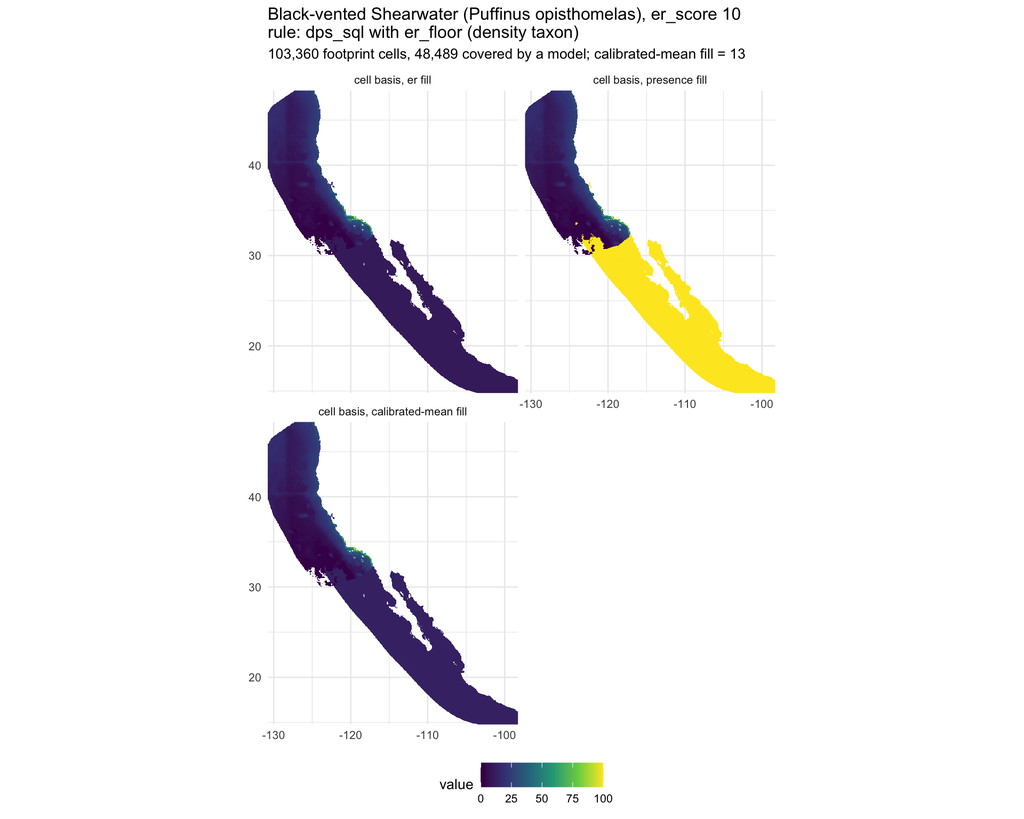

Figure 1: Black-vented shearwater: a Pacific density seabird (NCCOS survey inside its California Current domain, BirdLife range elsewhere). Under the er fill the unsurveyed range is worth 10; under presence 100; under the calibrated mean the survey’s domain mean.

```r
map_species("shearwater")
```

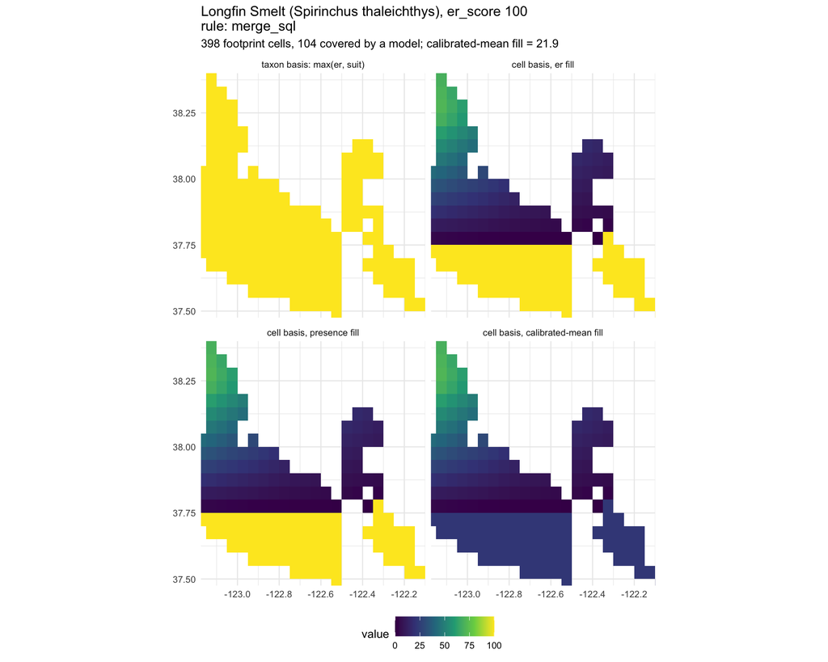

```r
map_species("smelt")
```

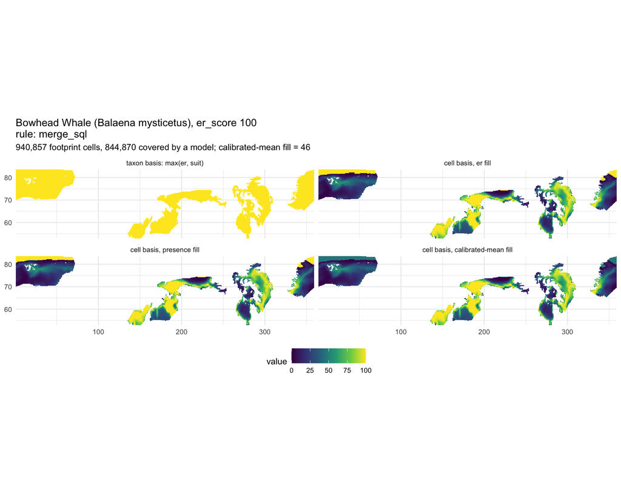

Figure 3: Bowhead whale (er_score 100): IUCN range and AquaMaps. The taxon basis paints the whole range 100; the cell basis is AquaMaps’ suitability inside the range, with the fill where AquaMaps has no cell.

```r
map_species("bowhead")
```

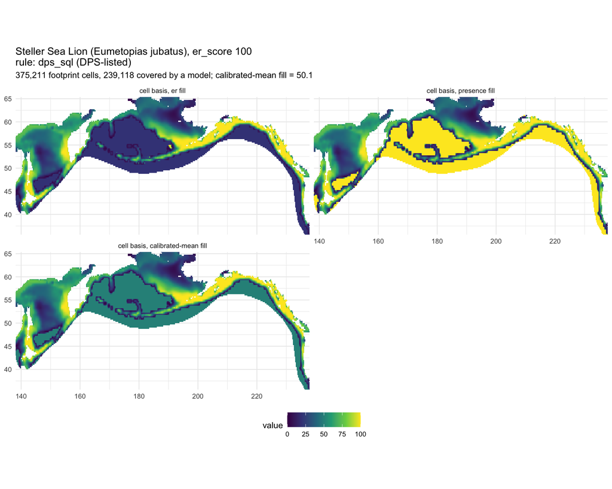

Figure 4: Steller sea lion: a DPS-listed species on the dps rule since v9 (no taxon basis exists for it). AquaMaps covers part of the listed footprint; the fill decides the rest, where today’s rule already uses the cell’s own risk.

```r
map_species("sealion")
```

## 5 Reading

```r
s <- shares |> group_by(species) |> summarise(across(where(is.numeric), ~ NA)) |> select(species)
pick <- function(k, setting, col) shares |> filter(species == k, setting == !!setting) |> pull(all_of(col))
cat(glue("
- **Shearwater** (density seabird): the fill decides its California vs Alaska weight. Southern California share: er fill {round(pick('shearwater','cell_er','SOC'), 1)} %, presence {round(pick('shearwater','cell_presence','SOC'), 1)} %, calibrated mean {round(pick('shearwater','cell_mean','SOC'), 1)} %. Northern California: {round(pick('shearwater','cell_er','NOC'), 2)} / {round(pick('shearwater','cell_presence','NOC'), 2)} / {round(pick('shearwater','cell_mean','NOC'), 2)} %. (The Alaska bird changes come from wider-ranging density seabirds whose BirdLife range reaches Alaska; this one stops at British Columbia.)
- **Longfin smelt** (range + AquaMaps, er 100): the taxon basis gives Central California {round(pick('smelt','taxon','CEC'), 1)} % of the species; the cell basis {round(pick('smelt','cell_er','CEC'), 1)} % (er fill), {round(pick('smelt','cell_presence','CEC'), 1)} % (presence), {round(pick('smelt','cell_mean','CEC'), 1)} % (mean). Here the basis matters more than the fill.
- **Bowhead** (range + AquaMaps, er 100): Hope Basin {round(pick('bowhead','taxon','HOP'), 2)} % under the taxon basis vs {round(pick('bowhead','cell_er','HOP'), 2)} / {round(pick('bowhead','cell_presence','HOP'), 2)} / {round(pick('bowhead','cell_mean','HOP'), 2)} % under the cell basis with the three fills.
- **Steller sea lion** (dps rule): Cook Inlet {round(pick('sealion','cell_er','COK'), 2)} % (today's er fill), {round(pick('sealion','cell_presence','COK'), 2)} % (presence), {round(pick('sealion','cell_mean','COK'), 2)} % (mean).

"))
```

- **Shearwater** (density seabird): the fill decides its California vs Alaska weight. Southern California share: er fill 10.7 %, presence 3.4 %, calibrated mean 9.5 %. Northern California: 7.14 / 1.28 / 6.2 %. (The Alaska bird changes come from wider-ranging density seabirds whose BirdLife range reaches Alaska; this one stops at British Columbia.)
- **Longfin smelt** (range + AquaMaps, er 100): the taxon basis gives Central California 50.4 % of the species; the cell basis 52.8 % (er fill), 52.8 % (presence), 50.8 % (mean). Here the basis matters more than the fill.
- **Bowhead** (range + AquaMaps, er 100): Hope Basin 0.56 % under the taxon basis vs 1.01 / 1.01 / 1.04 % under the cell basis with the three fills.
- **Steller sea lion** (dps rule): Cook Inlet 0.82 % (today’s er fill), 0.48 % (presence), 0.65 % (mean).

The table and maps say the same thing from two sides. The basis (max of risk and suitability vs suitability alone) changes the **shape** of a high-risk species’ surface wherever AquaMaps covers its range. The fill changes the **balance** between the modelled and unmodelled parts of a species’ footprint, and that balance is only an issue for species modelled over part of their range: the density seabirds above all, then the DPS species. For them `er` makes the unsurveyed range nearly weightless for a low-risk species and dominant for a high-risk one (the fill tracks the risk, which has nothing to do with how much of the species lives there), `presence` makes the unsurveyed range outweigh the survey, and the calibrated mean treats an unsurveyed cell as an average surveyed one, which is the only one of the three that does not depend on the risk score or on an arbitrary ceiling. It is not yet a flag; this notebook derives it after the fact.